# Лабораторная работа №6

Модель “хищник-жертва”

Демидович Н. М.

РУДН

15 марта 2024

# Информация

## Докладчик

- Демидович Никита Михайлович
- Студент группы НКНбд-01-22
- Студ. билет: 1132221550
- РУДН
- 1132221550@rudn.ru
- https://github.com/nikdem1

[figure not shown]

# Цели и задачи

## Цель

Научиться строить математическую модель “хищник–жертва”.

## Задача

Построить математическую модель “хищник–жертва”.

# Теоретическое введение

## Модель Лотки - Вольтерры

Модель Лотки - Вольтерры (или модель “хищник-жертва”) - математическая модель взаимодействия двух видов типа “хищник — жертва”, названная в честь своих авторов (Лотка, 1925; Вольтерра 1926), которые предложили модельные уравнения независимо друг от друга.

Такие уравнения можно использовать для моделирования систем “хищник - жертва”, “паразит - хозяин”, конкуренции и других видов взаимодействия между двумя видами.

Одним из примеров являются “акулы и сардины”: популяция сардин падает из-за объемного потребления их в пищу акулами, в связи с чем падает численность акул. После этого популяция сардин вновь возрастает, в связи с чем чуть позже вновь возрастает популяция акул, и так циклично - это отражается на графике.

# Ход выполнения работы

## Готовая модель “хищник–жертва”

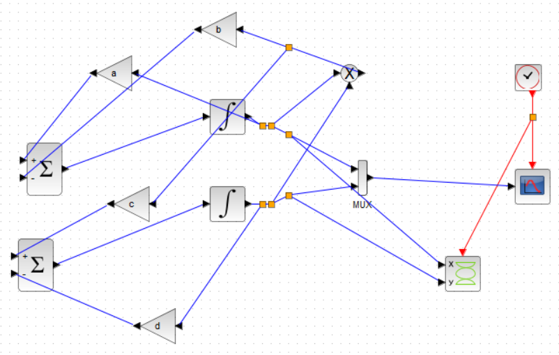

Модель “хищник–жертва”

## Реализация с применением блока Modelica, график и фазовый портрет

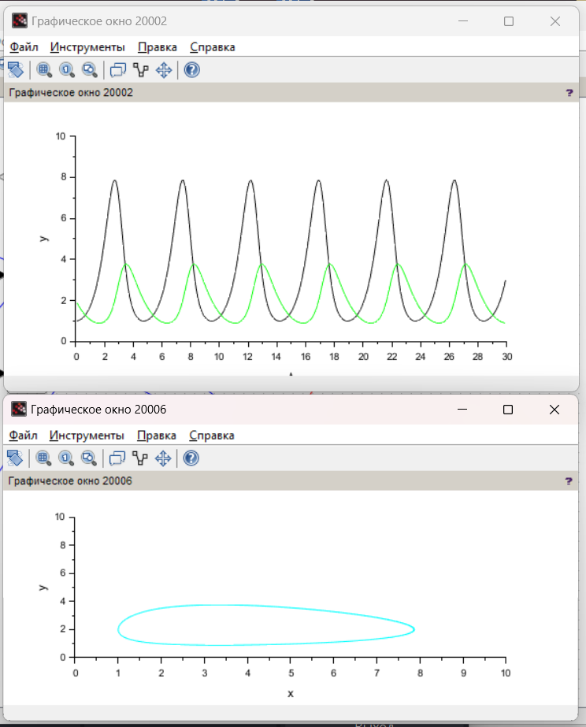

График динамики изменения численности хищников и жертв модели и фазовый портрет

# Результаты

## Выводы

В результате выполнения данной лабораторной работы я научился строить математическую модель “хищник–жертва”.